# Using a Hierarchical Model to Determine Optimal Price & Profit Forecasts for 2023 BSS Data Mining Challenge

Anubhav Shankar

2023-09-22

**Problem Statement:**

*The primary objective of this competition is to predict the optimal daily market prices for eCommerce products sold by BSS, with the goal of maximizing the profit. At present, BSS employs manual methods to analyze market variables and competitors’ prices to make pricing decisions. The manual methods, while functional, are not highly efficient and time-consuming. Given the technological advancements and the vast amount of data available, we believe there is a significant opportunity to develop innovative data-driven methods to quickly analyze market trends and make informed pricing decisions.*

The dataset for this competition comprises a set of market and sales variables from office products sold on the BSS eCommerce platform. The provided dataset spans over two and a half years, providing a comprehensive look at the market dynamics of more than 200 office products.The profitability of each product is determined by several factors. These factors include eCommerce revenue and various internal costs such as cost of goods sold (COGs), fulfillment fees, referral fees, and advertisement costs. BSS strategically adjusts product prices to maximize profitability, considering the prices set by competitors and customer demand responses.

However, the dynamic market prices make it challenging for the company to accurately predict the optimal price that will maximize profitability. The existing manual pricing decision process is not only time-consuming but also lacks the robustness that data-driven decision-making can potentially provide.

Consequently, there is a significant need to develop a data-driven process. This process should ideally determine the market price that yields the maximum profitability by analyzing the eCommerce market data. In summary, this data challenge seeks innovative solutions to effectively address this problem with two main goals:

• Determine the optimal selling price for an eCommerce product by leveraging more than two years of historical data comprising various sales and market variables.  
• Predict the expected daily profit for that product given a determined optimal selling price.

The developed solution should ideally lead to more profitable pricing decisions and strategies in a dynamic eCommerce market.  
**Abstract**: In the rapidly evolving world of eCommerce, strategic pricing plays a crucial role in driving profitability and competitive advantage. Accurate pricing influences consumer behavior and impacts a company’s bottom line. In industries with fierce competition and dynamic pricing, such as eCommerce, finding the optimal price for a product becomes a complex yet essential task. This task will be tackled by creating a hierarchical/mixed-effect model to predict the optimal volume and then optimize using a suitable profit function to obtain the optimal price. The optimal price will then be used to forecast the profit for the desired look ahead window.

Let’s have a quick glimpse of the metadata and see a few summary statistics below.

```r
# Visualize the metadata
str(bss)
```

```
## tibble [138,847 × 20] (S3: tbl_df/tbl/data.frame)
##  $ sku                    : chr [1:138847] "Envelopes SKU 4" "Envelopes SKU 4" "Envelopes SKU 4" "Envelopes SKU 4" ...
##  $ salesdate              : POSIXct[1:138847], format: "2022-01-01" "2022-01-02" ...
##  $ price                  : num [1:138847] 29.5 30 29.7 29.8 29.8 ...
##  $ unitsordered           : num [1:138847] 19 13 84 78 83 61 66 18 20 70 ...
##  $ sales                  : num [1:138847] 560 390 2494 2324 2473 ...
##  $ cogs                   : num [1:138847] 236 161 1042 968 1030 ...
##  $ fba                    : num [1:138847] 156 107 690 641 682 501 543 148 164 575 ...
##  $ reffee                 : num [1:138847] 84 58 374 349 371 273 290 81 90 314 ...
##  $ adspend                : num [1:138847] 0 0 0 0 0 0 0 0 0 0 ...
##  $ profit                 : num [1:138847] 84 64 388 366 390 292 281 88 98 334 ...
##  $ comp_1_price           : num [1:138847] 28.5 28.5 28.5 28.5 28.5 ...
##  $ comp_2_price           : num [1:138847] 28 28 28 28 28 ...
##  $ comp_3_price           : num [1:138847] 31 31 31 31 31 ...
##  $ comp_4_price           : num [1:138847] NA NA NA NA NA NA NA NA NA NA ...
##  $ comp_5_price           : logi [1:138847] NA NA NA NA NA NA ...
##  $ comp_data_min_price    : num [1:138847] 28 28 28 28 28 ...
##  $ comp_data_max_price    : num [1:138847] 31 31 31 31 31 ...
##  $ managed_fba_stock_level: num [1:138847] NA NA NA NA NA NA NA NA NA NA ...
##  $ min_price              : num [1:138847] 28 28 28 28 28 ...
##  $ max_price              : num [1:138847] 35 35 35 35 35 ...
```

```r
head(bss) # Get a pivot of the first few rows
```

```
## # A tibble: 6 × 20
##   sku    salesdate           price unitsordered sales  cogs   fba reffee adspend
##   <chr>  <dttm>              <dbl>        <dbl> <dbl> <dbl> <dbl>  <dbl>   <dbl>
## 1 Envel… 2022-01-01 00:00:00  29.5           19   560   236   156     84       0
## 2 Envel… 2022-01-02 00:00:00  30.0           13   390   161   107     58       0
## 3 Envel… 2022-01-03 00:00:00  29.7           84  2494  1042   690    374       0
## 4 Envel… 2022-01-04 00:00:00  29.8           78  2324   968   641    349       0
## 5 Envel… 2022-01-05 00:00:00  29.8           83  2473  1030   682    371       0
## 6 Envel… 2022-01-06 00:00:00  29.9           61  1823   757   501    273       0
## # ℹ 11 more variables: profit <dbl>, comp_1_price <dbl>, comp_2_price <dbl>,
## #   comp_3_price <dbl>, comp_4_price <dbl>, comp_5_price <lgl>,
## #   comp_data_min_price <dbl>, comp_data_max_price <dbl>,
## #   managed_fba_stock_level <dbl>, min_price <dbl>, max_price <dbl>
```

```r
summary(bss) # Get a basic data summary
```

```
##      sku              salesdate                          price
##  Length:138847      Min.   :2022-01-01 00:00:00.00   Min.   :  0.00
##  Class :character   1st Qu.:2022-06-17 00:00:00.00   1st Qu.: 15.89
##  Mode  :character   Median :2022-11-16 00:00:00.00   Median : 24.59
##                     Mean   :2022-11-15 10:42:09.56   Mean   : 22.22
##                     3rd Qu.:2023-04-17 00:00:00.00   3rd Qu.: 28.49
##                     Max.   :2023-09-16 00:00:00.00   Max.   :111.49
##
##   unitsordered        sales              cogs             fba
##  Min.   :  0.00   Min.   :    0.0   Min.   :   0.0   Min.   :   0.0
##  1st Qu.:  2.00   1st Qu.:   45.0   1st Qu.:  15.0   1st Qu.:  15.0
##  Median :  8.00   Median :  182.0   Median :  61.0   Median :  53.0
##  Mean   : 19.38   Mean   :  488.2   Mean   : 160.1   Mean   : 140.5
##  3rd Qu.: 23.00   3rd Qu.:  576.0   3rd Qu.: 186.0   3rd Qu.: 167.0
##  Max.   :833.00   Max.   :20900.0   Max.   :9654.0   Max.   :6847.0
##
##      reffee           adspend            profit          comp_1_price
##  Min.   :   0.00   Min.   :   0.00   Min.   :-4379.00   Min.   :  0.00
##  1st Qu.:   7.00   1st Qu.:   0.00   1st Qu.:    0.00   1st Qu.: 19.75
##  Median :  27.00   Median :   7.00   Median :   18.00   Median : 26.25
##  Mean   :  73.22   Mean   :  31.07   Mean   :   83.28   Mean   : 28.11
##  3rd Qu.:  86.00   3rd Qu.:  31.00   3rd Qu.:   85.00   3rd Qu.: 34.79
##  Max.   :3135.00   Max.   :1628.00   Max.   : 6753.00   Max.   :106.97
##                                                         NA's   :49406
##   comp_2_price     comp_3_price     comp_4_price    comp_5_price
##  Min.   :  0.00   Min.   : 0.00    Min.   : 0.00    Mode :logical
##  1st Qu.: 19.36   1st Qu.:15.88    1st Qu.:15.25    FALSE:30
##  Median : 25.99   Median :23.78    Median :21.97    TRUE :1983
##  Mean   : 27.46   Mean   :27.34    Mean   :27.06    NA's :136834
##  3rd Qu.: 32.72   3rd Qu.:32.64    3rd Qu.:29.99
##  Max.   :119.99   Max.   :81.46    Max.   :79.99
##  NA's   :84169    NA's   :115388   NA's   :130659
##  comp_data_min_price comp_data_max_price managed_fba_stock_level
##  Min.   :  0.00      Min.   :  0.00      Min.   :    0
##  1st Qu.: 17.99      1st Qu.: 21.56      1st Qu.:  284
##  Median : 24.70      Median : 29.15      Median :  685
##  Mean   : 26.05      Mean   : 31.38      Mean   : 1137
##  3rd Qu.: 30.48      3rd Qu.: 38.98      3rd Qu.: 1468
##  Max.   :119.99      Max.   :119.99      Max.   :20796
##  NA's   :42271       NA's   :42271       NA's   :24312
##    min_price       max_price
##  Min.   : 6.99   Min.   :  4.99
##  1st Qu.:16.99   1st Qu.: 23.99
##  Median :21.99   Median : 31.99
##  Mean   :22.92   Mean   : 32.88
##  3rd Qu.:25.99   3rd Qu.: 36.99
##  Max.   :91.99   Max.   :135.99
##
```

```r
max(bss$salesdate) # Get the ending date of the data
```

```
## [1] "2023-09-16 UTC"
```

```r
min(bss$salesdate) # Get the starting date of the data
```

```
## [1] "2022-01-01 UTC"
```

```r
length(unique(bss$sku)) # Get the number of unique Product IDs
```

```
## [1] 228
```

Let’s generate a pivot of NA values present in each column

```r
is_na_count <- bss %>% ungroup() %>% summarize_all(~sum(is.na(.))) %>% as.data.frame()  # Check the NA's in each field
# Use the ~ in the above formula as funs() has been deprecated
is_na_count
```

```
##   sku salesdate price unitsordered sales cogs fba reffee adspend profit
## 1   0         0     0            0     0    0   0      0       0      0
##   comp_1_price comp_2_price comp_3_price comp_4_price comp_5_price
## 1        49406        84169       115388       130659       136834
##   comp_data_min_price comp_data_max_price managed_fba_stock_level min_price
## 1               42271               42271                   24312         0
##   max_price
## 1         0
```

**Methodology**: A cursory glance through the abstract and the motivation sections might preordain using either a linear regression or a numerical method like extrapolation for the first objective and, consequently, use something like an Autoregressive Integrated Moving Average (ARIMA) for the second objective.

However, the methods above may fail to capture each product’s inherent volatility and dynamic demand curves. So, a hierarchical/mixed effect model is more suitable for such a purpose. Additionally, a parametric model will be less computationally intensive and more intuitive.

**Abbreviations and Acronyms**:

The following abbreviations will be used extensively throughout the document for brevity:  
i.) ME -> Mixed Effect  
ii.) ARIMA -> Autoregressive Integrated Moving Average  
iii.) LME -> Linear Mixed-Effect  
iv.) OLS -> Ordinary Least-Squares  
v.) RE -> Random Effect (can be used interchangeably with (i) & (iii))  
vi.) FFSKU47 -> File-Folders SKU 47

Before we proceed further let’s have a look at the time-series nature of the dataset and some preliminary insights.

```r
bss_season <- bss %>% dplyr::select(salesdate,revenue) %>% group_by(sku) # Create a temporary subset
```

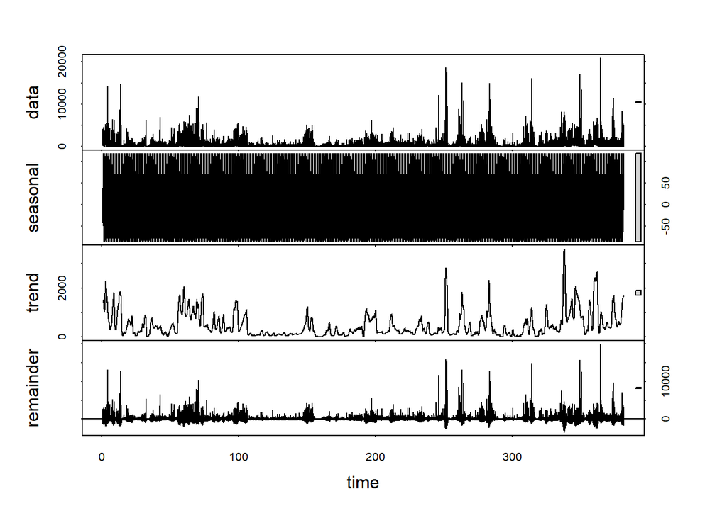

```r
bss_ts <- ts(bss_season$revenue,frequency = 365) # Capture the yearly seasonality

fit <- stl(bss_ts,s.window = "period")
plot(fit)
```

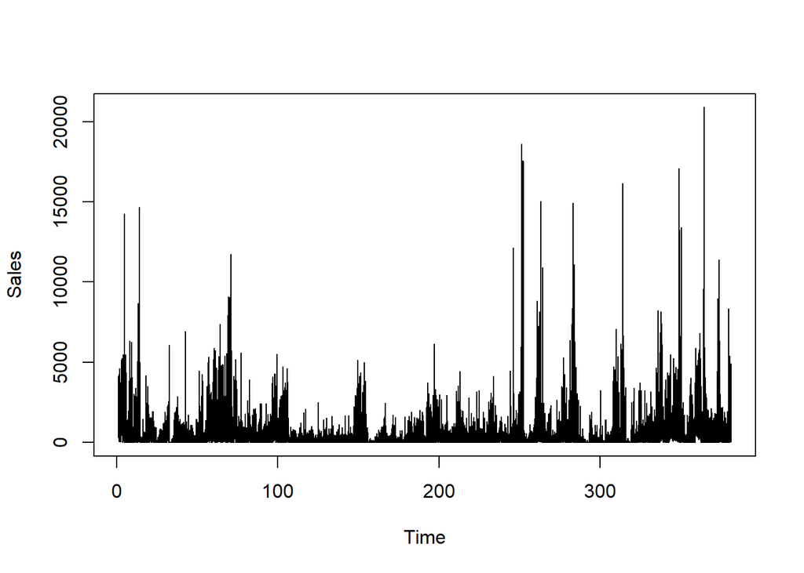

```r
additive_fit <- decompose(bss_ts,type = "additive")
multiplicative_fit <- decompose(bss_ts,type = "multiplicative")
plot(bss_ts,ylab = "Sales")
```

*After checking the ‘trend’ plot, we can confidently say that the seasonality of the plot is **additive***.

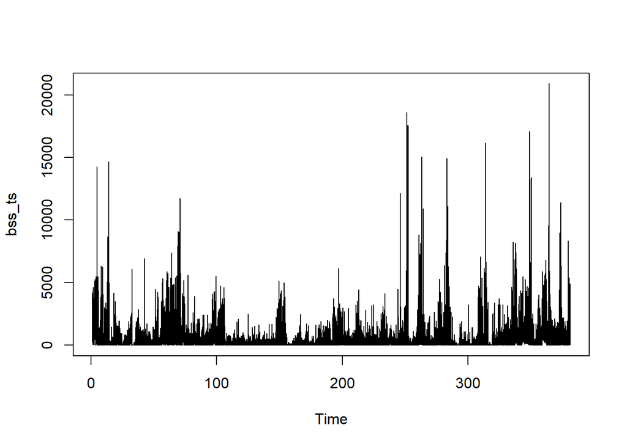

```r
# Do a basic time-series EDA of the sales over the entire period

# Visualize the inherent seasonality
# plot(bss_ts)
plot.ts(bss_ts)
```

```r
# Check stationarity
adf.test(diff(bss_ts)) # Augmented-Dickey Fuller Test
```

```
##
##  Augmented Dickey-Fuller Test
##
## data:  diff(bss_ts)
## Dickey-Fuller = -63.646, Lag order = 51, p-value = 0.01
## alternative hypothesis: stationary
```

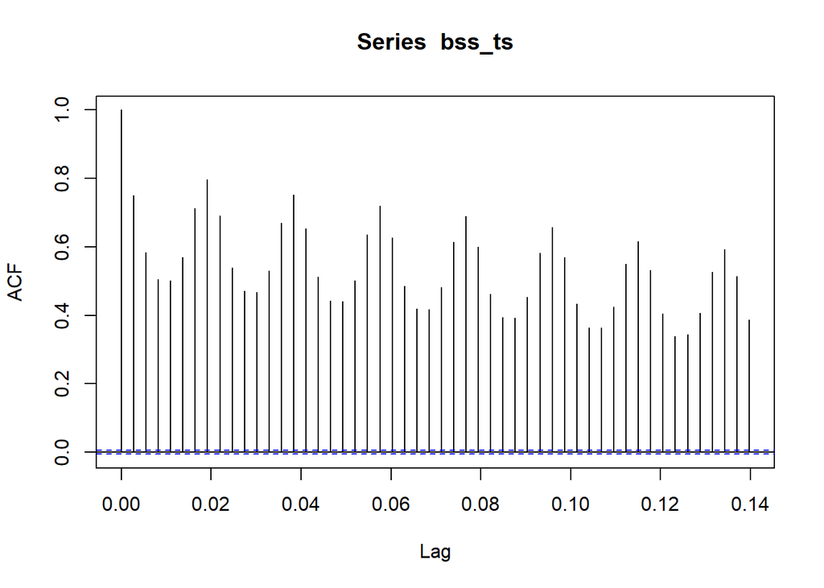

```r
acf(bss_ts) # Auto-Correlation Factor plot
```

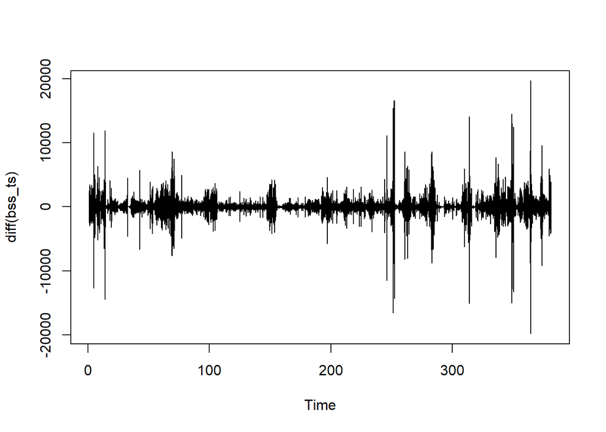

```r
plot(diff(bss_ts)) # Plot the data after rendering it stationary
```

```r
# Verify to see if the competitor counts match the problem document
comp_count_verification <- bss %>%
  group_by(sku) %>%
  summarise(unique_competitor_count = unique(competitor_count)) %>%
  group_by(unique_competitor_count) %>%
  summarise(num_of_items = n()) %>%
  arrange(unique_competitor_count)
```

[output not shown]

```r
comp_count_verification
```

```
## # A tibble: 6 × 2
##   unique_competitor_count num_of_items
##                     <dbl>        <int>
## 1                       0           90
## 2                       1          100
## 3                       2           78
## 4                       3           36
## 5                       4           10
## 6                       5            2
```

```r
# Visualize the competition
bss_temp <- bss %>% dplyr::select(prod_cat, price, all_of(comp_price_cols),competitor_count) %>% group_by(prod_cat)
```

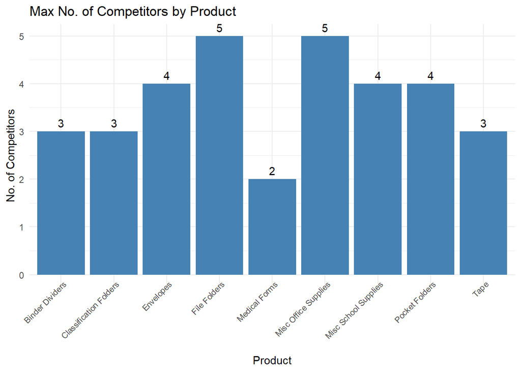

```r
total_competitors_by_product <- aggregate(bss_temp$competitor_count, by=list(product_name=bss_temp$prod_cat), FUN=max)
colnames(total_competitors_by_product)[2] <- "competitors" # Rename the second element of the list; 'x' by default
ggplot(total_competitors_by_product,aes(x=product_name, y=competitors)) +
  geom_bar(stat = "identity", fill = "steelblue") +
  # geom_smooth(aes(group=1), method="loess", color="red", se=FALSE) +
  geom_text(aes(label = competitors), vjust = -0.5) +
  labs(title = "Max No. of Competitors by Product",
       x = "Product",
       y = "No. of Competitors") +
  theme_minimal() +
  theme(axis.text.x = element_text(angle = 45, hjust = 1, vjust = 1.2, size = 8)) # Rotate the axis labels to make them more legible
```

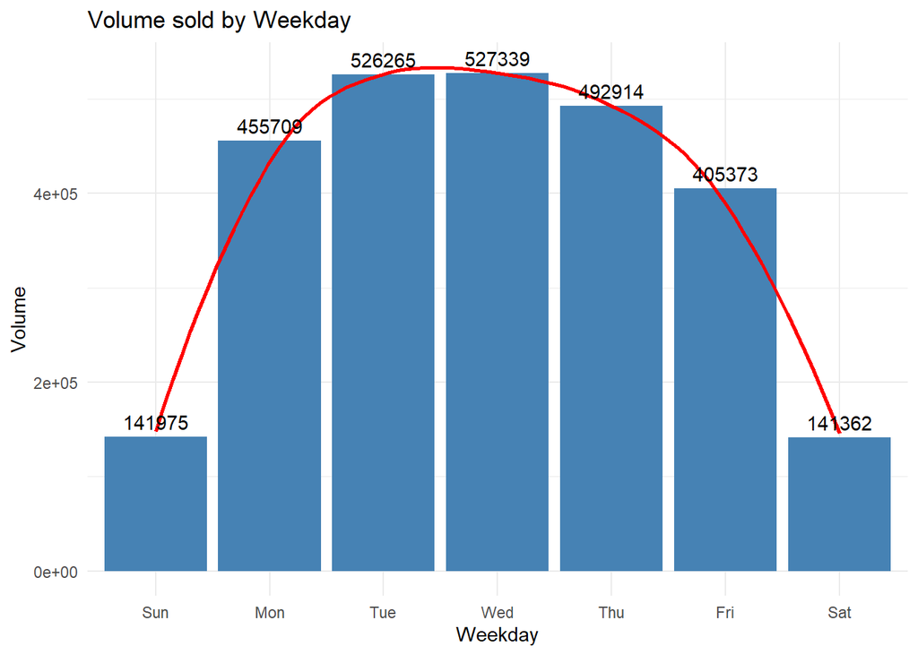

```r
# Check the distribution of the 'volume' field
weekday_totals <- aggregate(bss$volume, by=list(weekday=bss$weekday), FUN=sum)
colnames(weekday_totals)[2] <- "volume"
ggplot(weekday_totals,aes(x=weekday, y=volume)) +
  geom_bar(stat = "identity", fill = "steelblue") +
  geom_smooth(aes(group=1), method="loess", color="red", se=FALSE) +
  geom_text(aes(label = volume), vjust = -0.5) +
  labs(title = "Volume sold by Weekday",
       x = "Weekday",
       y = "Volume") +
  theme_minimal()
```

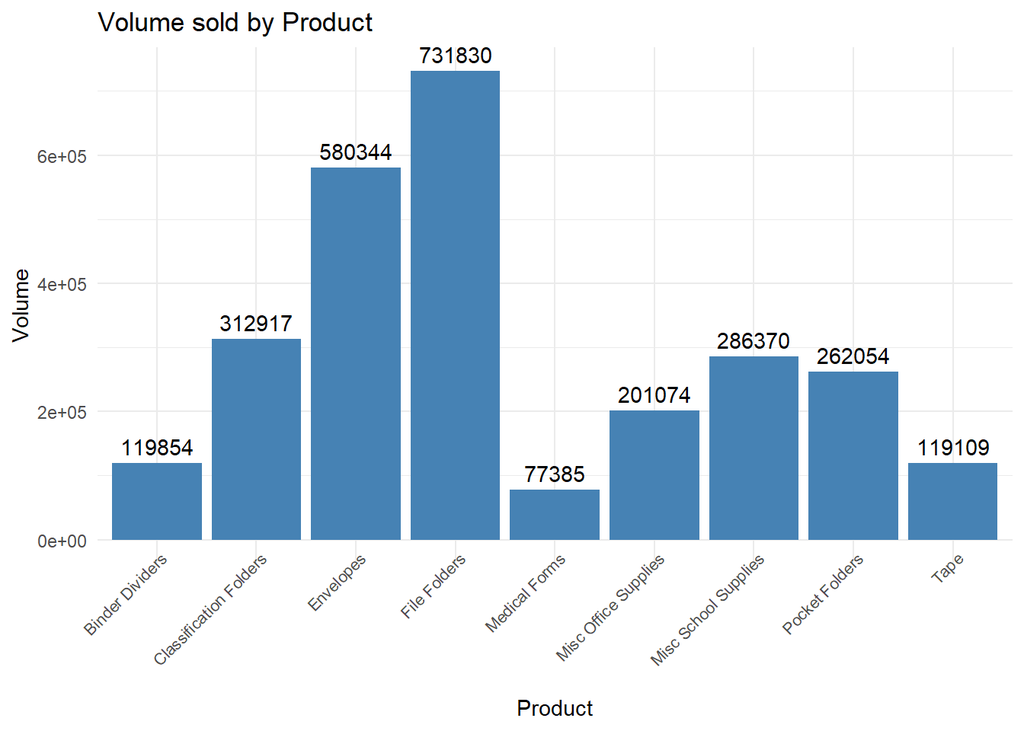

```r
# Check the distribution of the volume sold by the Product
product_totals <- aggregate(bss$volume, by=list(product_name=bss$prod_cat), FUN=sum)
colnames(product_totals)[2] <- "volume" # Rename the second element of the list; 'x' by default
ggplot(product_totals,aes(x=product_name, y=volume)) +
  geom_bar(stat = "identity", fill = "steelblue") +
  # geom_smooth(aes(group=1), method="loess", color="red", se=FALSE) +
  geom_text(aes(label = volume), vjust = -0.5) +
  labs(title = "Volume sold by Product",
       x = "Product",
       y = "Volume") +
  theme_minimal() +
  theme(axis.text.x = element_text(angle = 45, hjust = 1, vjust = 1.2, size = 8)) # Rotate the axis labels to make them more legible
```

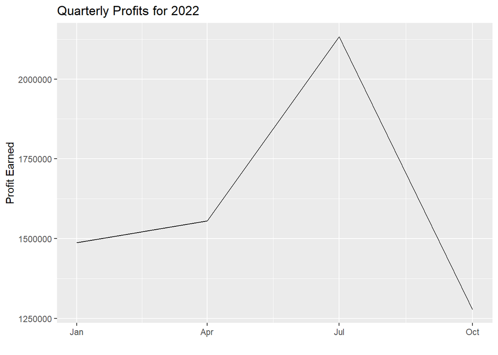

```r
# Filter for data in 2022
recent_profit <- bss %>%
  filter(year(salesdate) == 2022) %>%
  # Group by quarter and summarize the profit
  group_by(Qtr = quarter) %>%
  summarise(Total_Profit = sum(profit, na.rm = TRUE)) %>%
  ungroup()
# Convert the data to a time series object
profit_ts <- ts(recent_profit$Total_Profit, start = c(2022,1), frequency = 4)
# Plot
autoplot(profit_ts) + labs(y ="Profit Earned", title = "Quarterly Profits for 2022")
```

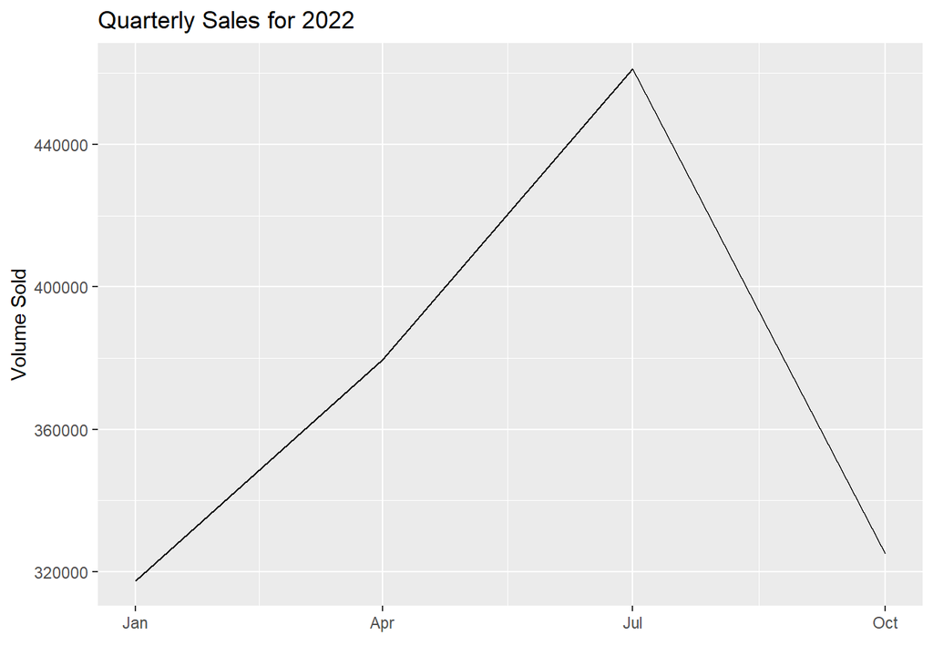

```r
recent_sales <- bss %>%
  filter(year(salesdate) == 2022) %>%
  # Group by quarter and summarize the sales
  group_by(Qtr = quarter) %>%
  summarise(Total_Sales = sum(volume, na.rm = TRUE)) %>%
  ungroup()
sales_ts <- ts(recent_sales$Total_Sales, start = c(2022,1), frequency = 4)
autoplot(sales_ts) + labs(y ="Volume Sold", title = "Quarterly Sales for 2022")
```

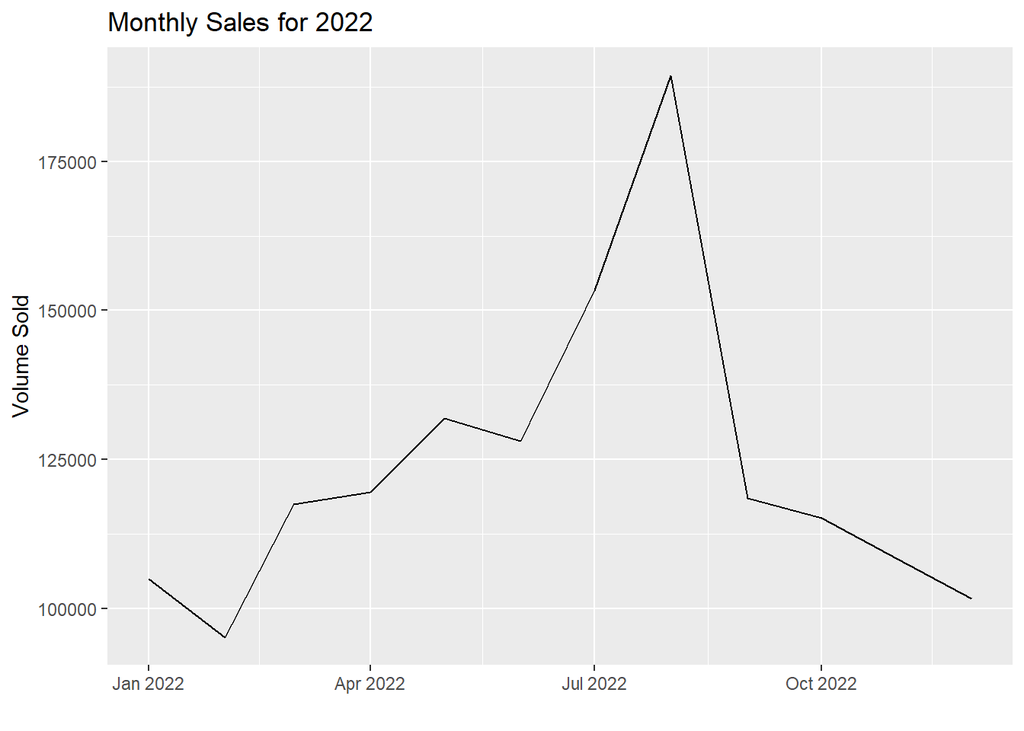

```r
monthly_sales <- bss %>%
  filter(year(salesdate) == 2022) %>%
  # Group by quarter and summarize the sales
  group_by(Month = month) %>%
  summarise(Total_Sales_m = sum(volume, na.rm = TRUE)) %>%
  ungroup()
monthly_sales_ts <- ts(monthly_sales$Total_Sales_m, start = c(2022,1), frequency = 12)
autoplot(monthly_sales_ts) + labs(y ="Volume Sold", title = "Monthly Sales for 2022")
```

The figures above show that sales and profits fell sharply around the end of August. Additionally, the volume distribution on the day-to-day sales shows the sales distribution is nearly normal, with Saturday as the worst-performing day. Such nuances will be useful to control for.

Additionally, there are nearly **230 individual products** that are sold. However, they can be **grouped into nine (9) distinct types/categories**, as shown in the graph above that tracks the sales performance of each category. **‘File Folders’** is the **best-performing product type/category**. Concurrently, we also know that each product can have multiple competitors. A bird’s eye view of the competition indicates that in addition to being the best-performing product category, **‘File Folders’ also has the highest number of competitors**.

As observed earlier, all the competitor prices have a large amount of missing values. Let’s see the distribution of the seller price and the competitor prices respectively.

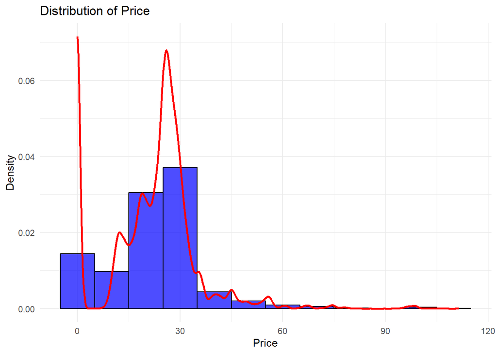

```r
# Create a histogram to see the spread of the 'price' field
ggplot(bss, aes(x = price)) +
  geom_histogram(aes(y = after_stat(density)), binwidth = 10, fill = "blue", color = "black", alpha = 0.7) +
  geom_density(color = "red", linewidth = 1) + # plot a superimposing density curve
  theme_minimal() +
  labs(title = "Distribution of Price", x = "Price", y = "Density")
```

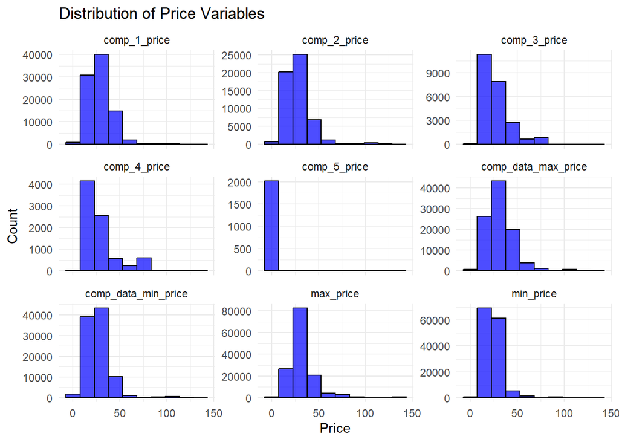

```r
# Let's see the distribution of all the price variables

# Convert data to long format
bss_long <- bss %>%
  pivot_longer(cols = contains("_price"), # A regex operation
               names_to = "Price_Variable",
               values_to = "Price_Value",
               values_drop_na = TRUE)

# Plot using ggplot2
ggplot(bss_long, aes(x = Price_Value)) +
  geom_histogram(fill = "blue", color = "black", alpha = 0.7, bins = 10) +
  facet_wrap(~Price_Variable, scales = "free_y") + # Customize each plot basis it's respective range
  theme_minimal() +
  labs(title = "Distribution of Price Variables", x = "Price", y = "Count")
```

All prices seem to have a noticeable and distinct right skew. Concurrently, there have been instances where either BSS or one of the competitor seems to have sold a product for **$0 or charged a price near the market upper threshold**.

While these overarching insights are helpful, let us dive deeper and see the demand curves for the ‘File Folders’ category and our assigned ‘sku’, ‘FFSKU 47’ for a snapshot in time.

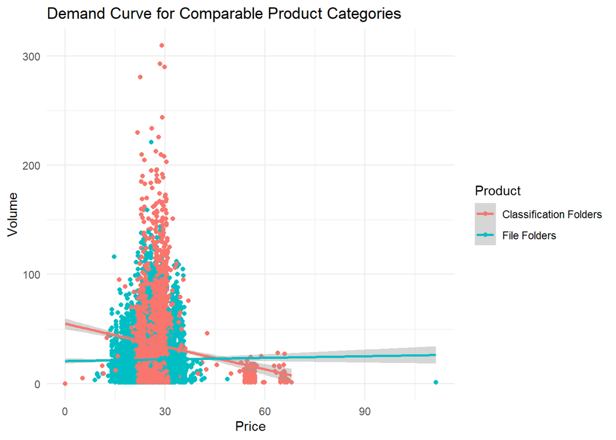

```r
bss_pivot <- bss %>% filter(salesdate >= "2022-01-01" & salesdate <= "2022-08-31") %>% dplyr::select(sku, price, revenue, volume, prod_cat) %>% distinct()


product_category <- c("File Folders", "Classification Folders")
bss_pivot %>% filter(prod_cat %in% product_category) %>%
  ggplot(aes(x = price, y = volume, color = prod_cat)) +
  geom_point() +
  geom_smooth(method = "lm", se = TRUE) +
  labs(title = "Demand Curve for Comparable Product Categories",
       x = "Price",
       y = "Volume",
       color = "Product") +
  theme_minimal()
```

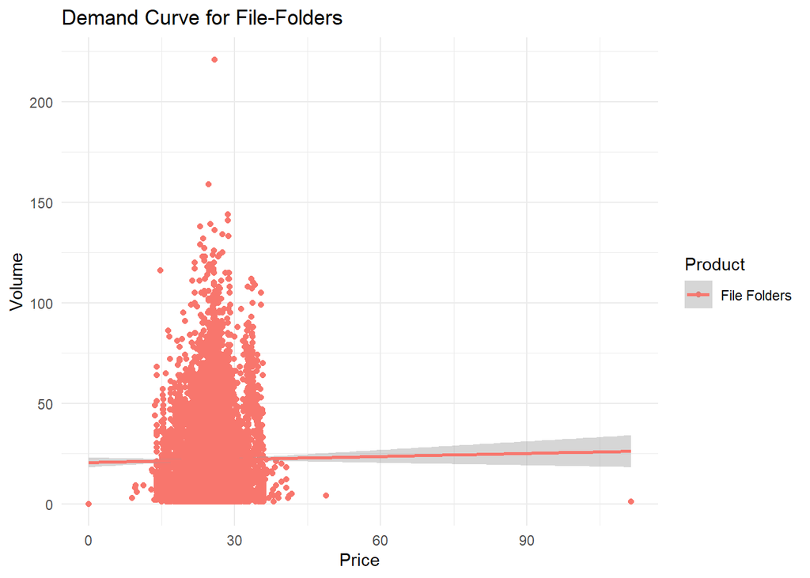

```r
product_category <- c("File Folders")
bss_pivot %>% filter(prod_cat %in% product_category) %>%
  ggplot(aes(x = price, y = volume, color = prod_cat)) +
  geom_point() +
  geom_smooth(method = "lm", se = TRUE) +
  labs(title = "Demand Curve for File-Folders",
       x = "Price",
       y = "Volume",
       color = "Product") +
  theme_minimal()
```

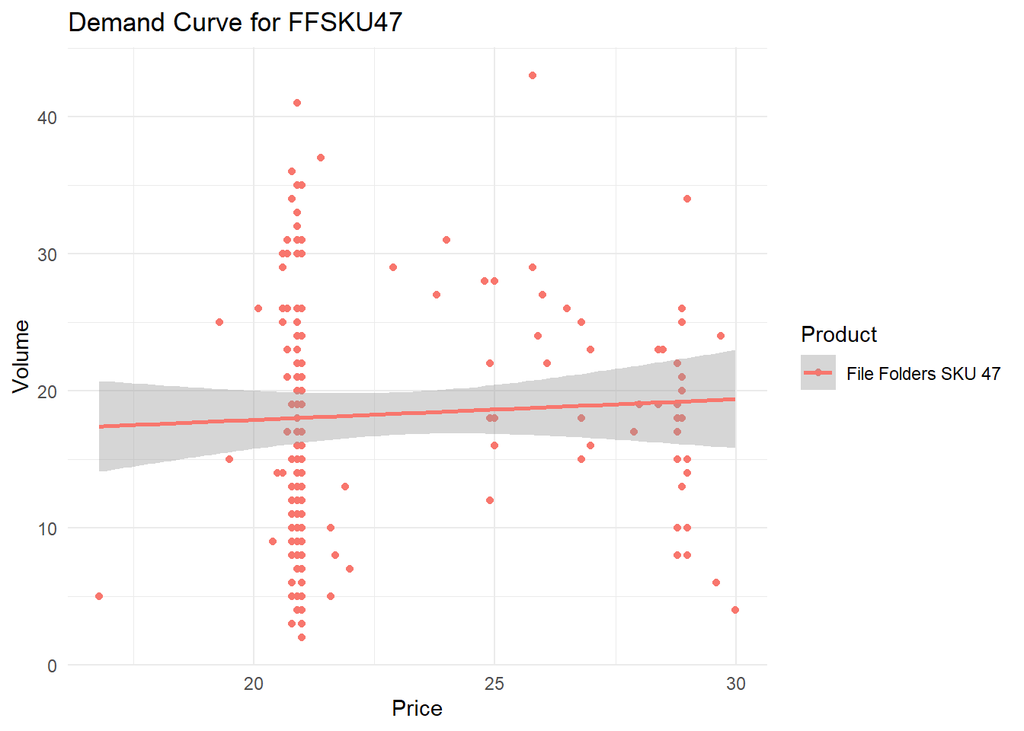

```r
# product_name <- c("File Folders SKU 47","File Folders SKU 20")
product_name <- c("File Folders SKU 47")
bss_pivot %>% filter(sku %in% product_name) %>%
  ggplot(aes(x = price, y = volume, color = sku)) +
  geom_point() +
  geom_smooth(method = "lm", se = TRUE) +
  labs(title = "Demand Curve for FFSKU47",
       x = "Price",
       y = "Volume",
       color = "Product") +
  theme_minimal()
```

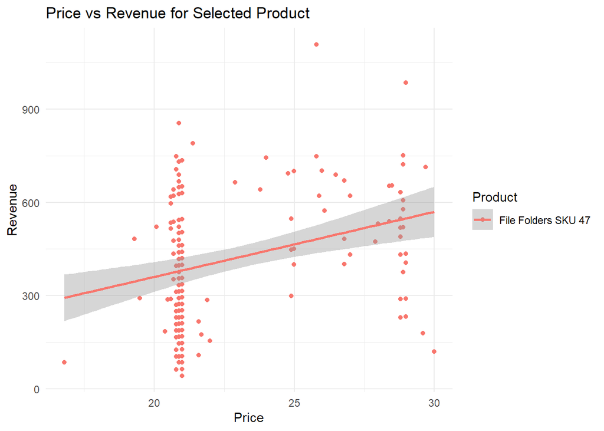

```r
# bss_pivot <- bss %>% filter(salesdate >= "2022-01-01" & salesdate <= "2022-07-13") %>% dplyr::select(sku, price, revenue, prod_cat) %>% distinct()
product_name <- c("File Folders SKU 47")
bss_pivot %>% filter(sku %in% product_name) %>%
ggplot(aes(x = price, y = revenue, color = sku)) +
geom_point() +
geom_smooth(method = "lm", se = TRUE) +
labs(title = "Price vs Revenue for Selected Product",
x = "Price",
y = "Revenue",
color = "Product") +
theme_minimal()
```

We’ll create the training and validation sets below.

```r
seed <- 123
set.seed(seed = seed) # Set seed for reproducibility

bss_train <- bss %>% filter(salesdate <= "2023-05-31") # Create the training set
bss_val <- bss %>% filter(salesdate >= "2023-06-01" & sku == "File Folders SKU 47") # Create the validation set

glimpse(bss_train)
```

```
## Rows: 114,166
## Columns: 29
## Groups: sku [228]
## $ sku                 <fct> Envelopes SKU 4, Envelopes SKU 4, Envelopes SKU 4,…
## $ salesdate           <date> 2022-01-01, 2022-01-02, 2022-01-03, 2022-01-04, 2…
## $ price               <dbl> 29.49, 29.99, 29.69, 29.79, 29.79, 29.89, 29.29, 2…
## $ volume              <dbl> 19, 13, 84, 78, 83, 61, 66, 18, 20, 70, 102, 91, 1…
## $ revenue             <dbl> 560, 390, 2494, 2324, 2473, 1823, 1933, 540, 600, …
## $ cogs                <dbl> 236, 161, 1042, 968, 1030, 757, 819, 223, 248, 869…
## $ fba                 <dbl> 156, 107, 690, 641, 682, 501, 543, 148, 164, 575, …
## $ reffee              <dbl> 84, 58, 374, 349, 371, 273, 290, 81, 90, 314, 453,…
## $ adspend             <dbl> 0, 0, 0, 0, 0, 0, 0, 0, 0, 0, 0, 0, 0, 0, 0, 0, 0,…
## $ profit              <dbl> 84, 64, 388, 366, 390, 292, 281, 88, 98, 334, 461,…
## $ comp_1_price        <dbl> 28.49, 28.49, 28.49, 28.49, 28.49, 28.49, 28.49, 2…
## $ comp_2_price        <dbl> 27.97, 27.97, 27.97, 27.97, 27.97, 27.97, 27.97, 2…
```

[output cut: 17 more lines]

```r
glimpse(bss_val)
```

```
## Rows: 109
## Columns: 29
## Groups: sku [1]
## $ sku                 <fct> File Folders SKU 47, File Folders SKU 47, File Fol…
## $ salesdate           <date> 2023-06-01, 2023-06-02, 2023-06-03, 2023-06-04, 2…
## $ price               <dbl> 27.39, 27.89, 27.99, 27.99, 27.69, 27.89, 27.89, 2…
## $ volume              <dbl> 16, 8, 5, 2, 4, 6, 14, 11, 1, 2, 0, 4, 6, 0, 2, 2,…
## $ revenue             <dbl> 438, 223, 140, 56, 111, 167, 390, 307, 22, 56, 0, …
## $ cogs                <dbl> 89, 44, 28, 11, 22, 33, 78, 61, 6, 11, 0, 22, 33, …
## $ fba                 <dbl> 127, 63, 40, 16, 32, 47, 111, 87, 8, 16, 0, 32, 47…
## $ reffee              <dbl> 66, 33, 21, 8, 17, 25, 58, 46, 3, 8, 0, 17, 25, 0,…
## $ adspend             <dbl> 0, 0, 0, 0, 0, 0, 0, 0, 0, 0, 0, 0, 0, 0, 0, 0, 0,…
## $ profit              <dbl> 156, 83, 51, 21, 40, 62, 143, 113, 5, 21, 0, 40, 6…
## $ comp_1_price        <dbl> 35.37, 29.80, 29.80, 29.80, 29.80, 29.80, 29.80, 2…
## $ comp_2_price        <dbl> 27.26, 25.34, 25.34, 25.34, 25.34, 25.34, 25.34, 2…
```

[output cut: 17 more lines]

**Mixed Effect Models & Approach**: Also known as Linear Mixed-Effect models, it is primarily used for modeling a mixture of fixed and random effects. Fixed effects refer to the typical main effects one would see in a linear regression model, i.e., the non-random part of a mixed model. In some contexts, they are referred to as the population average effect. Random effects are simply those specific to an observational unit, however defined. In our case, the observational units would be the products themselves.

The lmer() command, part of the ‘lme4’ package, can run an ME model in R [1].

We will create an ME model to predict the optimal volume and optimize it using the optim() command in the lme4 package to get an optimal price point.

Mathematically,

```
     Volume = 1 + β1 * X1 + β2 * X2  + β3 * X3 + β4 * X4  + β5 * X5  +  β6 * X6  +  γ  * X7  +  εi                               - (1)

   In Eq(1), X1, X2, …… X7 -> The independent variables on which the dependent variable, ‘volume,’ will be modeled.
```

where,  
εi -> The error/residual term  
X1 -> comp_1_price  
*X2 -> comp_2_price*  
X3 -> cost  
X4 -> Markup; coded as I(price-cost)  
X5 -> salesdate  
X6 -> weekday  
X7 -> RE of cost for each ‘sku’; coded as (1 + cost | sku), the ‘1’ represents the intercept for the RE

**Note: While the File Folders product category has five competitors, FFSKU47 only has two. Hence, only two competitor prices have been included in the model**.

```r
bss_hierachical_cost_product_intercept <- lmer(volume ~ 1 + comp_1_price + comp_2_price + cost + I(price - cost) + salesdate + weekday + (1 + cost | sku), data = bss_train, REML = TRUE) # Hierarchical/Mixed-Effect Model

ranef(bss_hierachical_cost_product_intercept) # Coefficients of the random effects
```

```
## $sku
##                               (Intercept)          cost
## Binder Dividers SKU 10        -0.44350720  0.0624987458
## Binder Dividers SKU 11        -0.53003200  0.0200777477
## Binder Dividers SKU 8          0.09026593  0.0273414316
## Classification Folders SKU 1  -0.04265351 -0.0046533217
## Classification Folders SKU 10 -0.10659057 -0.0010098811
## Classification Folders SKU 14 -0.27506031 -0.0085406447
## Classification Folders SKU 15  0.08846459 -0.0111066757
## Classification Folders SKU 3   0.22862649 -0.0094946399
## Classification Folders SKU 4   0.29039495 -0.0089238639
## Classification Folders SKU 7   0.16171636 -0.0060055130
## Envelopes SKU 1                0.52646027 -0.0142651705
## Envelopes SKU 10              -0.52821393  0.0000338188
## Envelopes SKU 12               1.26185141 -0.0129695910
## Envelopes SKU 13              -0.14824271 -0.0070143851
## Envelopes SKU 15               2.90640180  0.0310247209
## Envelopes SKU 16              -0.20588670  0.0147469188
## Envelopes SKU 17              -1.18742813 -0.0106849254
## Envelopes SKU 2                0.71747655 -0.0166023758
## Envelopes SKU 23               0.13383712 -0.0187686735
## Envelopes SKU 24               0.39980393 -0.0137307849
## Envelopes SKU 25              -0.14437051 -0.0027426762
## Envelopes SKU 29               0.15990727 -0.0255312131
## Envelopes SKU 3                0.66975229 -0.0165216838
## Envelopes SKU 31              -0.29555666  0.0057974105
## Envelopes SKU 4                0.61557448 -0.0170919835
## Envelopes SKU 5                0.56312047 -0.0122856241
## Envelopes SKU 6               -0.13654488 -0.0122070250
## Envelopes SKU 7                0.62798239 -0.0159825441
## Envelopes SKU 9                1.64024783 -0.0154490818
## File Folders SKU 14            0.28589045 -0.0020168794
## File Folders SKU 15            0.04981274 -0.0146540915
## File Folders SKU 17            0.42042131 -0.0171966784
## File Folders SKU 19            0.13501983  0.0074352224
## File Folders SKU 20           -0.07447752  0.0019955771
## File Folders SKU 25            0.34232444 -0.0083615387
## File Folders SKU 3             0.20554888 -0.0106302276
## File Folders SKU 47            0.43481888  0.0004248875
## File Folders SKU 48            0.22035722  0.0306959059
```

[output cut: 38 more lines]

```
## Misc School Supplies SKU 18    0.13754718 -0.0277966967
## Misc School Supplies SKU 23    0.02544959 -0.0037571819
## Misc School Supplies SKU 3    -0.10099940  0.0392681828
## Misc School Supplies SKU 6     0.70538103 -0.0246894069
## Misc School Supplies SKU 7    -1.10225667 -0.0304630987
## Pocket Folders SKU 10         -1.31765919  0.0169682943
## Pocket Folders SKU 5           0.98869409 -0.0245322621
## Pocket Folders SKU 7          -1.61215203  0.0341878753
## Pocket Folders SKU 8          -1.98998779  0.0288323654
## Pocket Folders SKU 9          -1.26830569  0.0593981947
## Tape SKU 1                     1.51218274  0.0125315741
## Tape SKU 3                     0.19498078  0.0066122975
## Tape SKU 4                     0.37301012  0.0002758214
##
## with conditional variances for "sku"
```

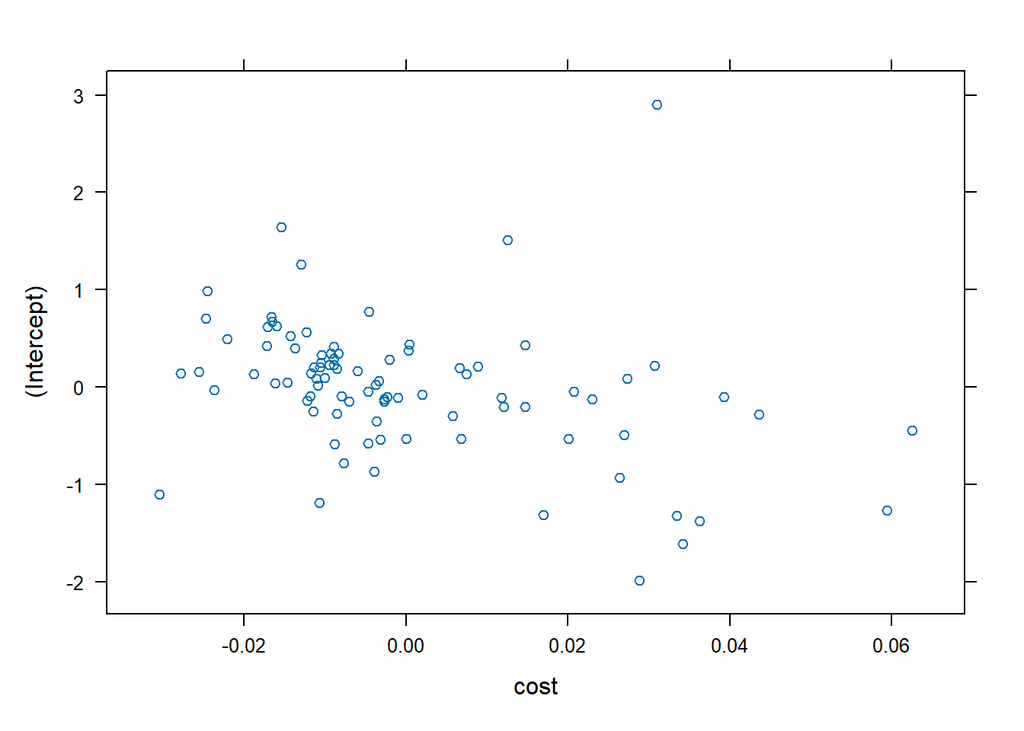

```r
plot(ranef(bss_hierachical_cost_product_intercept)) # Plots the cost vs. intercept variance
```

```r
summary(bss_hierachical_cost_product_intercept) # Coefficients of the mixed & random effects
```

```
## Linear mixed model fit by REML ['lmerMod']
## Formula: volume ~ 1 + comp_1_price + comp_2_price + cost + I(price - cost) +
##     salesdate + weekday + (1 + cost | sku)
##    Data: bss_train
##
## REML criterion at convergence: 185094.8
##
## Scaled residuals:
##      Min       1Q   Median       3Q      Max
## -31.1900  -0.1771   0.0050   0.2026  27.9598
##
## Random effects:
##  Groups   Name        Variance  Std.Dev. Corr
##  sku      (Intercept) 10.928183 3.30578
##           cost         0.001168 0.03417  -0.85
##  Residual              6.217151 2.49342
## Number of obs: 39397, groups:  sku, 89
##
## Fixed effects:
##                   Estimate Std. Error t value
## (Intercept)      4.946e+01  1.772e+00  27.915
## comp_1_price    -3.026e-03  3.012e-03  -1.004
## comp_2_price    -9.191e-03  3.120e-03  -2.946
## cost             3.437e-02  4.120e-03   8.344
## I(price - cost) -2.088e-02  1.987e-03 -10.508
## salesdate       -2.547e-03  9.131e-05 -27.893
## weekdayMon       6.519e-02  4.908e-02   1.328
## weekdayTue      -5.761e-02  5.006e-02  -1.151
## weekdayWed      -8.660e-02  5.002e-02  -1.731
## weekdayThu       2.622e-02  4.970e-02   0.528
## weekdayFri       9.977e-02  4.866e-02   2.050
## weekdaySat      -1.329e-02  4.738e-02  -0.281
##
## Correlation of Fixed Effects:
##             (Intr) cmp_1_ cmp_2_ cost   I(-cs) salsdt wkdyMn wekdyT wkdyWd
## comp_1_pric  0.187
## comp_2_pric  0.057 -0.168
## cost        -0.178  0.011 -0.005
## I(pric-cst) -0.064  0.025 -0.007  0.475
## salesdate   -0.978 -0.229 -0.095  0.020  0.041
## weekdayMon  -0.019  0.010  0.023 -0.030 -0.054  0.006
## weekdayTue  -0.017  0.011  0.027 -0.029 -0.050  0.005  0.552
## weekdayWed  -0.017  0.013  0.027 -0.030 -0.052  0.005  0.553  0.563
## weekdayThu  -0.020  0.012  0.025 -0.028 -0.049  0.008  0.548  0.557  0.557
## weekdayFri  -0.017  0.008  0.019 -0.032 -0.061  0.005  0.537  0.541  0.542
## weekdaySat  -0.017 -0.002  0.000  0.001  0.001  0.004  0.480  0.471  0.472
##             wkdyTh wkdyFr
## comp_1_pric
## comp_2_pric
## cost
## I(pric-cst)
## salesdate
## weekdayMon
## weekdayTue
## weekdayWed
## weekdayThu
## weekdayFri   0.538
## weekdaySat   0.475  0.484
## optimizer (nloptwrap) convergence code: 0 (OK)
## unable to evaluate scaled gradient
## Model failed to converge: degenerate  Hessian with 1 negative eigenvalues
```

```r
predictions <- predict(bss_hierachical_cost_product_intercept, newdata = bss_val)
bss_val$pred_vol <- round(predictions,0)

stargazer(bss_hierachical_cost_product_intercept, type = "text", title = "Random Effect Results", summary = TRUE) # Tabulate the summary of the model
```

```
##
## Random Effect Results
## ===============================================
##                         Dependent variable:
##                     ---------------------------
##                               volume
## -----------------------------------------------
## comp_1_price                  -0.003
##                               (0.003)
##
## comp_2_price                 -0.009***
##                               (0.003)
##
## cost                         0.034***
##                               (0.004)
##
## I(price - cost)              -0.021***
##                               (0.002)
##
## salesdate                    -0.003***
##                              (0.0001)
##
## weekdayMon                     0.065
##                               (0.049)
##
## weekdayTue                    -0.058
##                               (0.050)
##
## weekdayWed                    -0.087*
##                               (0.050)
##
## weekdayThu                     0.026
##                               (0.050)
##
## weekdayFri                    0.100**
##                               (0.049)
##
## weekdaySat                    -0.013
##                               (0.047)
##
## Constant                     49.464***
##                               (1.772)
##
## -----------------------------------------------
## Observations                  39,397
## Log Likelihood              -92,547.410
## Akaike Inf. Crit.           185,126.800
## Bayesian Inf. Crit.         185,264.100
## ===============================================
## Note:               *p<0.1; **p<0.05; ***p<0.01
```

The profit function conducts a row-wise operation by multiplying the predicted volume with the optimal price and subtracting the static costs. The ME model and the profit function are then fed into the optim() command within the defined bounds to arrive at the optimal price point.

```r
# Create a profit function to get the maximum profit using the predicted volume and optimal price

profit_function <- function(price, model, df) {

            predicted_volume <- predict(model, newdata = transform(df, price = price)) # Predict the volume of sales for the given price by replacing the existing prices with the optimum prices using the transform() function

            profit <- price * predicted_volume - df$cost # A row-wise operation to calculate the max profit for each day

            return(-sum(profit, na.rm = TRUE)) #*
          #* Use the negative sign to maximize for the profit as optim() by default
          #  minimizes the function value.

}

# Optimizer Function

initial_guess <- median(bss_val$price, na.rm = TRUE) # Initial value for optimizing

# Set the bounds for the optimizer function
lower_limit <- min(bss_val$price, na.rm = TRUE)
upper_limit <- max(bss_val$price, na.rm = TRUE)

result <- optim(

    par = initial_guess,
    fn = profit_function,
    model = bss_hierachical_cost_product_intercept,
    df = bss_val,
    method = "L-BFGS-B", # A memory efficient high-dimensional optimization method that allows the set up of requisite constraint boundaries.
    lower = lower_limit,
    upper = upper_limit

)

t <- round_to_constraint(result$par) # Obtain the optimal price
print(paste0("Optimal Price: ", "$",t))
```

```
## [1] "Optimal Price: $28.05"
```

```r
temp <- bss_val %>% filter(salesdate > "2023-08-31" & salesdate <= "2023-09-11")

# Remove the last two rows
if (nrow(temp) > 2) {
temp <- temp[-((nrow(temp) - 1):(nrow(temp))), ] #Deletes the last two rows
} else {
# Handle the case where you have two or fewer rows
warning("Data frame has two or fewer rows. Cannot remove last two rows.")
}

temp$salesdate <- seq(from = as.Date("2023-09-17"), to = as.Date("2023-09-25"), by = "day")
temp$weekday <- wday(temp$salesdate, label = TRUE) # Introduce a weekday instrumental variable
temp$price <- t
temp$pred_vol <- round(predict(bss_hierachical_cost_product_intercept, newdata = temp, re.form = NA),0)
temp$pred_profit <- (temp$price * temp$pred_vol) - temp$cost

vv <- mape(bss_val$volume, bss_val$pred_vol)
print(paste0("Volume MAPE_Validation: ", vv, "%"))
```

```
## [1] "Volume MAPE_Validation: 21.6%"
```

```r
vt <- mape(temp$volume, temp$pred_vol)
print(paste0("Volume MAPE_Test: ", vt, "%"))
```

```
## [1] "Volume MAPE_Test: 4.52%"
```

```r
p <- mape(temp$profit, temp$pred_profit)
print(paste0("Profit MAPE: ", p, "%"))
```

```
## [1] "Profit MAPE: 74.43%"
```

a.) Less computationally intensive  
b.) Intuitive and relatively easy to replicate  
c.) The chosen variables lead to a relatively parsimonious model  
**Acknowledgement**: This project has been a challenging endeavor. I want to thank Neal Fultz, Statistical Scientist, UCLA (nfultz@ucla.edu), for his valuable insights and fine-tuning my approach to the problem by familiarizing me with hierarchical models.  
**References**:

1.) Mixed Models with R  
2.) Intro to R Stats: Hierarchical Linear Models  
3.) Forecasting Principles & Practice (a) & (b)  
4.) Hierarchical Linear Modeling (HLM): An Introduction to Cross-Sectional & Growth Modeling Frameworks  
5.) lme4: Linear Mixed-Effects Models